# Simple Modeling in R

Markus Loecher, Berlin School of Economics and Law

```r
#define our own transformation
require(scales) # trans_new() is in the scales library
sign_sqrt_trans = function() trans_new("sign_sqrt", function(x) sign(x)*sqrt(abs(x)), function(x) sign(x)*x^2)
```

# 1 Simple data summaries

## 1.1 Titanic

```r
train <- read.csv("data/TitanicTrain.csv")
```

The disaster was famous for saving “women and children first”, so let’s take a look at the Sex and Age variables to see if any patterns are evident. We’ll start with the gender of the passengers. After reloading the data into R, take a look at the summary of this variable:

```r
round(prop.table(table(train$Sex, train$Survived),1),2)
```

```
##
##             0    1
##   female 0.26 0.74
##   male   0.81 0.19
```

Let’s create a new variable, “Child”, to indicate whether the passenger is below the age of 18:

```r
train$Child <- 0
train$Child[train$Age < 18] <- 1
```

Now we want to create a table with both gender and age to see the survival proportions for different subsets. Recall the dplyr version of the aggregate function:

```r
#summarise(group_by(train, Sex, Child), round(mean(Survived),2), length(Survived))
options(digits=3)

train %>% group_by(Sex, Child) %>%
  summarize(propSurvived = mean(Survived),
            sampleSize = length(Survived))
```

```
## # A tibble: 4 x 4
## # Groups:   Sex [2]
##   Sex    Child propSurvived sampleSize
##   <fct>  <dbl>        <dbl>      <int>
## 1 female     0        0.753        259
## 2 female     1        0.691         55
## 3 male       0        0.166        519
## 4 male       1        0.397         58
```

While the class variable is limited to a manageable 3 values, the fare is again a continuous variable that needs to be reduced to something that can be easily tabulated. Let’s bin the fares into less than $10, between $10 and $20, $20 to $30 and more than $30 and store it to a new variable:

```r
train$Fare2 <- '30+'
 train$Fare2[train$Fare < 30 & train$Fare >= 20] <- '20-30'
 train$Fare2[train$Fare < 20 & train$Fare >= 10] <- '10-20'
train$Fare2[train$Fare < 10] <- '<10'
```

- Use the summarise function to compute the proportions and in each group defined by child, gender and Fare2:

```
## # A tibble: 16 x 5
## # Groups:   Child, Fare2 [8]
##    Child Fare2 Sex    propSurvived sampleSize
##    <dbl> <chr> <fct>         <dbl>      <int>
##  1     0 <10   male          0.104        259
##  2     0 10-20 male          0.122         90
##  3     1 <10   male          0.154         13
##  4     0 20-30 male          0.215         65
##  5     0 30+   male          0.324        105
##  6     1 20-30 male          0.357         14
##  7     1 30+   male          0.4           20
##  8     1 20-30 female        0.545         11
##  9     0 <10   female        0.561         57
## 10     1 30+   female        0.632         19
## 11     0 10-20 female        0.717         60
## 12     0 20-30 female        0.717         46
## 13     1 10-20 male          0.727         11
## 14     1 10-20 female        0.778         18
## 15     1 <10   female        0.857          7
## 16     0 30+   female        0.906         96
```

- Find strong differences between male/female survival probabilities.
- Partition your data into even finer subgroups, e.g. age and/or embarkation port and repeat.

```
## # A tibble: 41 x 6
## # Groups:   Child, Fare2, Sex [16]
##    Child Fare2 Sex    Embarked propSurvived sampleSize
##    <dbl> <chr> <fct>  <fct>           <dbl>      <int>
##  1     0 <10   female C              1               2
##  2     0 <10   female Q              0.696          23
##  3     0 <10   female S              0.438          32
##  4     0 <10   male   C              0.133          30
##  5     0 <10   male   Q              0.0714         28
##  6     0 <10   male   S              0.104         201
##  7     0 10-20 female C              0.444           9
##  8     0 10-20 female Q              0.833           6
##  9     0 10-20 female S              0.756          45
## 10     0 10-20 male   C              0.455          11
## # ... with 31 more rows
```

# 2 Linear Models

```r
fit = lm(Survived ~ Sex, data = train)
summary(fit)
```

```
##
## Call:
## lm(formula = Survived ~ Sex, data = train)
##
## Residuals:
##    Min     1Q Median     3Q    Max
## -0.742 -0.189 -0.189  0.258  0.811
##
## Coefficients:
##             Estimate Std. Error t value Pr(>|t|)
## (Intercept)   0.7420     0.0231    32.2   <2e-16 ***
## Sexmale      -0.5531     0.0287   -19.3   <2e-16 ***
## ---
## Signif. codes:  0 '***' 0.001 '**' 0.01 '*' 0.05 '.' 0.1 ' ' 1
##
## Residual standard error: 0.409 on 889 degrees of freedom
## Multiple R-squared:  0.295,  Adjusted R-squared:  0.294
## F-statistic:  372 on 1 and 889 DF,  p-value: <2e-16
```

```r
fit = lm(Survived ~ Sex + Pclass, data = train)
summary(fit)
```

```
##
## Call:
## lm(formula = Survived ~ Sex + Pclass, data = train)
##
## Residuals:
##     Min      1Q  Median      3Q     Max
## -0.9252 -0.2505 -0.0925  0.2328  0.9075
##
## Coefficients:
##             Estimate Std. Error t value Pr(>|t|)
## (Intercept)   1.0833     0.0403    26.9   <2e-16 ***
## Sexmale      -0.5167     0.0274   -18.9   <2e-16 ***
## Pclass       -0.1580     0.0157   -10.1   <2e-16 ***
## ---
## Signif. codes:  0 '***' 0.001 '**' 0.01 '*' 0.05 '.' 0.1 ' ' 1
##
## Residual standard error: 0.387 on 888 degrees of freedom
## Multiple R-squared:  0.368,  Adjusted R-squared:  0.366
## F-statistic:  258 on 2 and 888 DF,  p-value: <2e-16
```

Try to reframe our exercises from above into linear models.

- Think about
  - factors
  - significance

## 2.1 Correlation

#### 2.1.0.1 Are arrival and departure delay correlated?

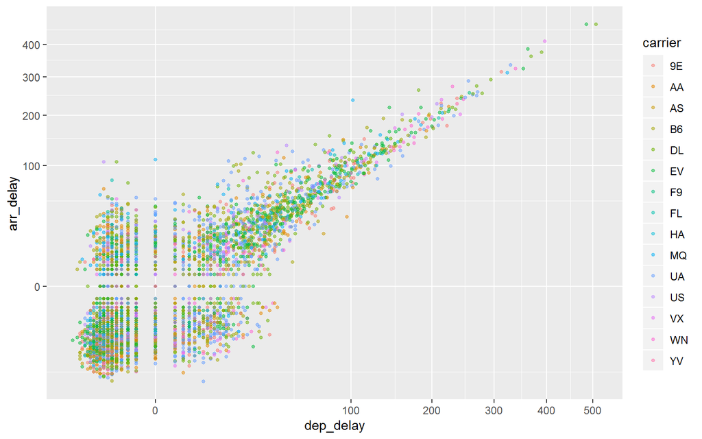

```r
set.seed(Sys.Date())
ranRows=sample(nrow(flights),5000)

if (baseR){
  plot(arr_delay ~ dep_delay, data=flights[ranRows,], pch=20,cex=0.5,col=carrier)
  grid()
} else {
  p = ggplot(flights[ranRows,], aes( dep_delay,arr_delay, col=carrier ))
  p + geom_point( alpha=0.5, size=1) + coord_trans(x="sign_sqrt", y="sign_sqrt") # +  geom_smooth(method=lm)
}
```

```r
cor(flights$dep_delay,flights$arr_delay, use = "complete.obs",method = "pearson")
```

```
## [1] 0.915
```

```r
#slooow
#cor(flights$dep_delay,flights$arr_delay, use = "complete.obs",method = "kendall")

#cor(flights$dep_delay,flights$arr_delay, use = "complete.obs",method = "spearman")

Shortdelays = filter(flights, abs(arr_delay)<100 & abs(dep_delay)<100)

cor(Shortdelays$dep_delay,Shortdelays$arr_delay, use = "complete.obs",method = "pearson")
```

```
## [1] 0.756
```

```r
#plot(arr_delay ~ dep_delay,data=Shortdelays)
```

## 2.2 simple regression

### 2.2.1 mpg vs. weight

```r
library(ISLR);data(Auto)
```

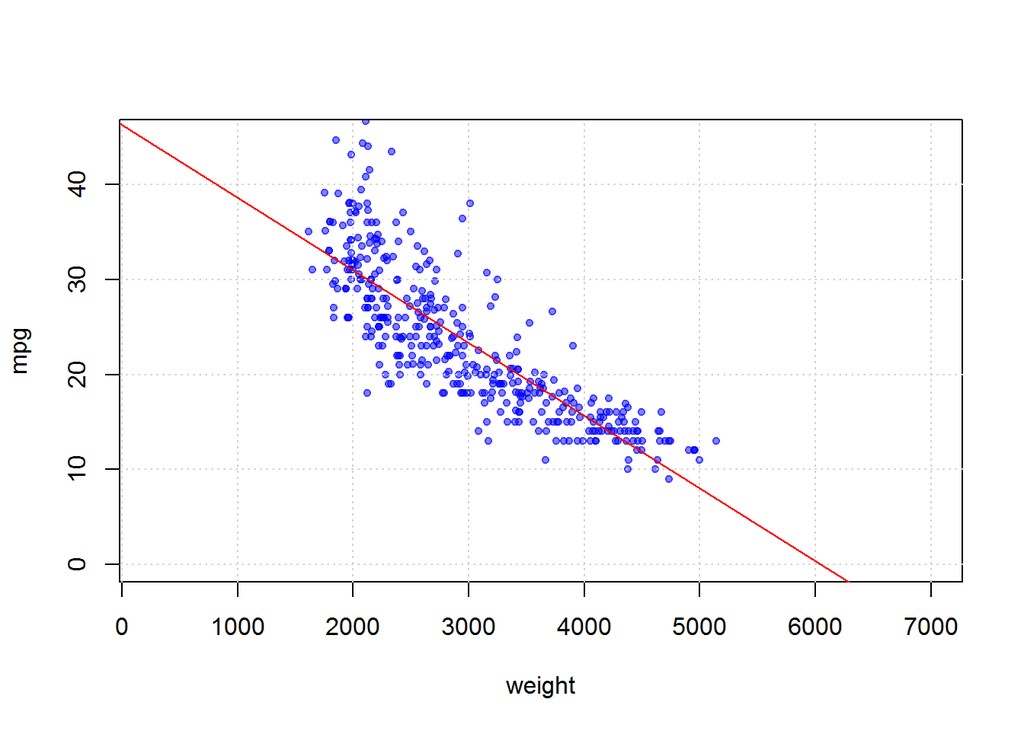

```r
plot(mpg ~ weight, data = Auto,col = rgb(0,0,1,0.5), pch=20,xlim=c(250, 7000), ylim = c(0,45));grid()
LSfit = lm(mpg ~ weight, data = Auto)

#overlay regression line
abline(LSfit, col=2)
```

```r
#summary
summary(LSfit)
```

```
##
## Call:
## lm(formula = mpg ~ weight, data = Auto)
##
## Residuals:
##     Min      1Q  Median      3Q     Max
## -11.974  -2.756  -0.336   2.138  16.519
##
## Coefficients:
##              Estimate Std. Error t value Pr(>|t|)
## (Intercept) 46.216525   0.798672    57.9   <2e-16 ***
## weight      -0.007647   0.000258   -29.6   <2e-16 ***
## ---
## Signif. codes:  0 '***' 0.001 '**' 0.01 '*' 0.05 '.' 0.1 ' ' 1
##
## Residual standard error: 4.33 on 390 degrees of freedom
## Multiple R-squared:  0.693,  Adjusted R-squared:  0.692
## F-statistic:  879 on 1 and 390 DF,  p-value: <2e-16
```

```r
#diagnostics
#plot(LSfit, c(1,2,5))
```

**Tasks**

1. Predict mpg for a car that weighs 5000 lbs.
2. Confidence Interval for slope
3. Are the least squares assumptions met?
4. Add 3 outliers to the data:
- weight=500, mpg = 40
- weight=$10^4$, mpg = 80
- weight=3000, mpg = 80

Points that fall horizontally far from the line are points of high leverage; these points can strongly influence the slope of the least squares line. If one of these high leverage points does appear to actually invoke its in uence on the slope of the line then we call it an in uential point. Usually we can say a point is influential if, had we fitted the line without it, the influential point would have been unusually far from the least squares line.

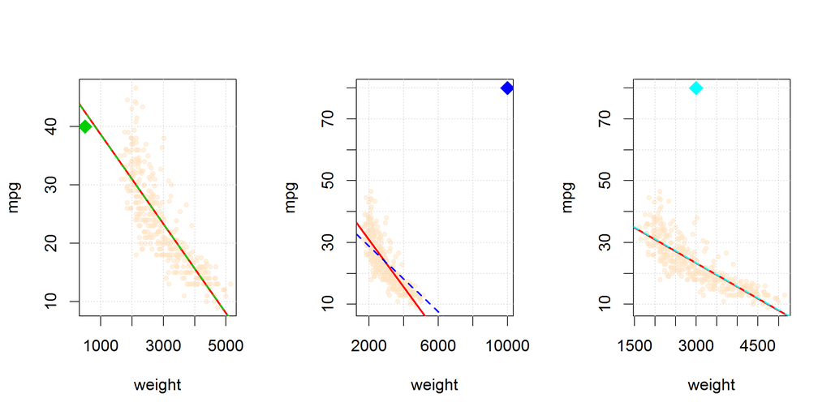

```r
par(mfrow=c(1,3), cex=1.4)

outlrs = cbind(weight=c(500,10000,3000),mpg=c(40,80,80))
Auto2 = Auto

fit=list()
for (i in 1:3){
  Auto2[1,c("weight","mpg")] = outlrs[i,]

  plot(mpg ~ weight, data = Auto2,col = rgb(1,0.894,0.769,0.5), pch=20);grid()
  #overlay regression line
  abline(LSfit, col=2, lwd=2.5)
  fit[[i]] = lm(mpg ~ weight, data = Auto2)
  points(Auto2[1,c("weight","mpg")], col = i+2, pch = 18, cex = 2)
  #overlay regression line
  abline(fit[[i]], col=i+2,lwd=2, lty=2)
  #plot(fit[[i]],5)
}
```